# Climate Vulnerability Indicators for Salmon

## Overview

The preliminary outputs below compare the PCIC gridded model projections for the historic period of 1971-2000 to the future period of 2041-2070. For each CU and time period, the average indicator value for grid cells within the CU boundary is calculated and plotted.

**Temperature Indicators:**  
POT19freq - number of days per year above 19deg  
POT19dur - length of consecutive days above 19 degrees

### Data sources

**BCFishPass** - using a version developed for PSF including observed and modelled presence/absence by species and life stage (spawning and rearing). Currently this is only used for plotting in the outputs for each CU, but future versions will consider specific overlap between streams and grid cells for more accurate statistical summaries of indicators.

**CU boundaries** - spatial boundaries for CUs based on Freshwater Adaptive Zones. Taken from PSF data library [https://data.salmonwatersheds.ca/result?datasetid=104]  
**PCIC gridded model output** - indicators from the Salmon Climate Impacts portal [https://pacificclimate.org/analysis-tools/salmon-climate-impacts-portal]

## Comparisons of PCIC indicators for Fraser CUs

These plots show indicator values for all CUs in the Fraser Basin comparing the historic to future time period. The dashed 1:1 line represents similar conditions between historic and future periods.

### Flow indicators

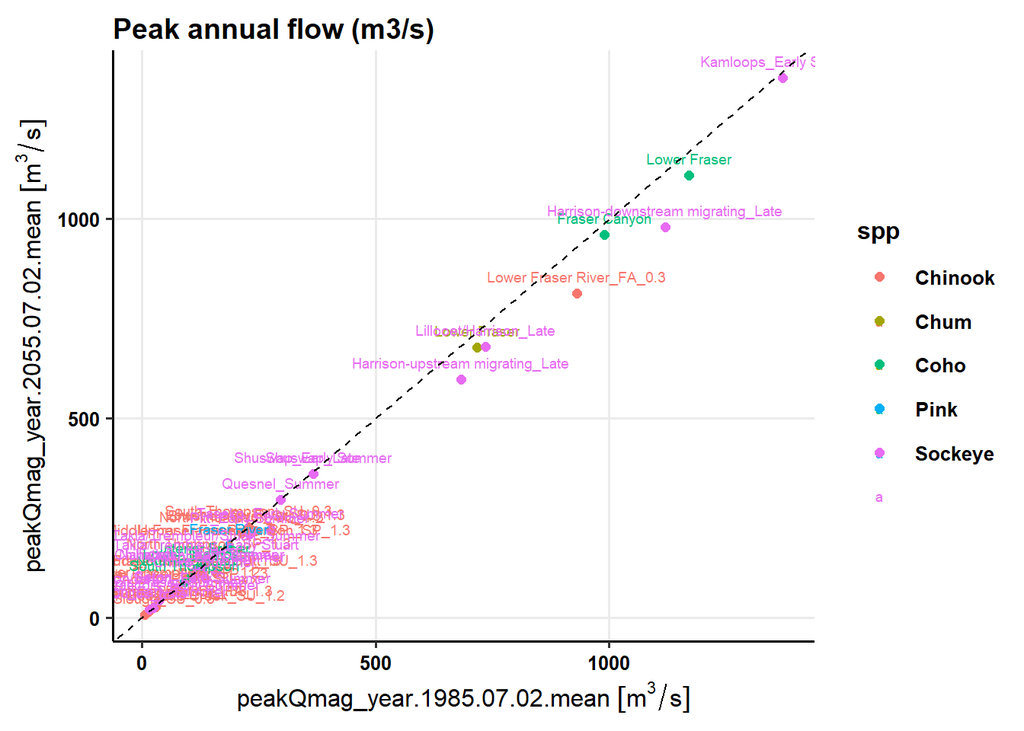

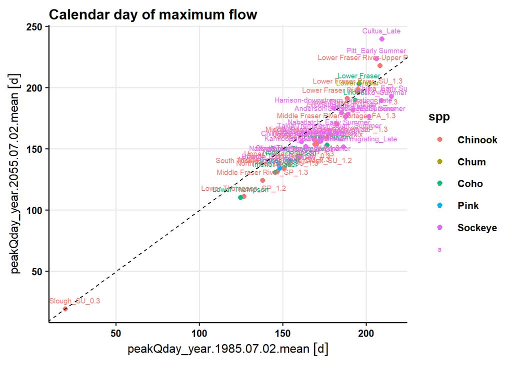

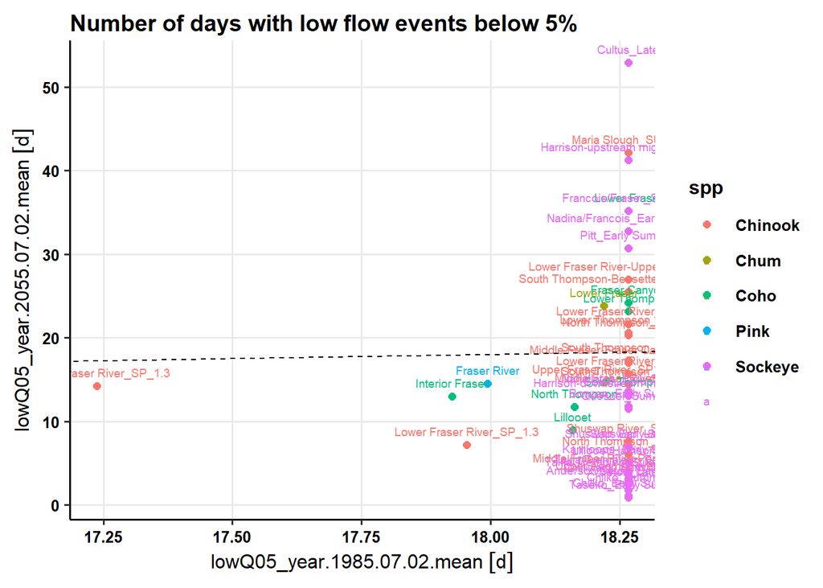

### Temperature indicators

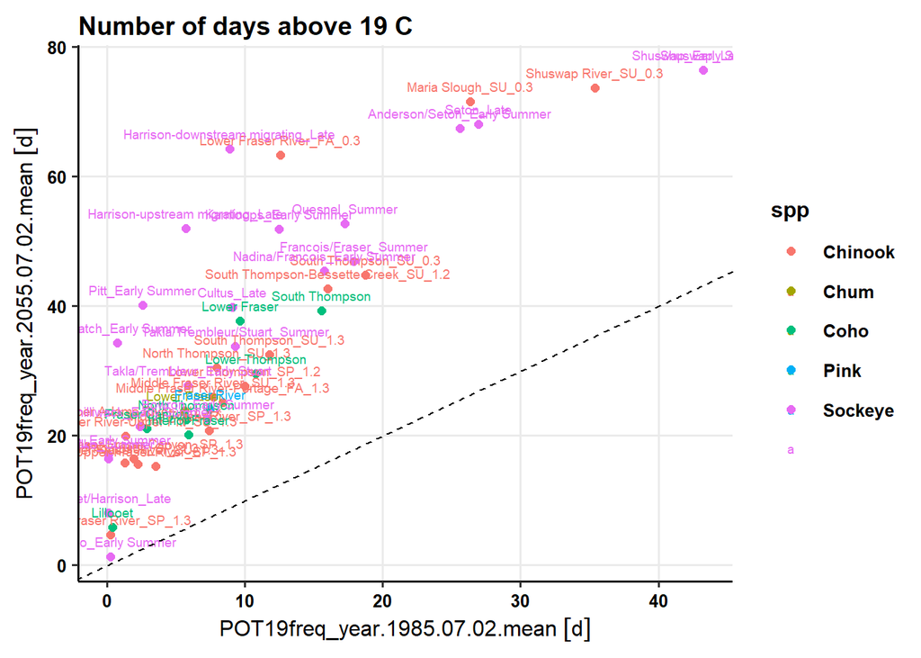

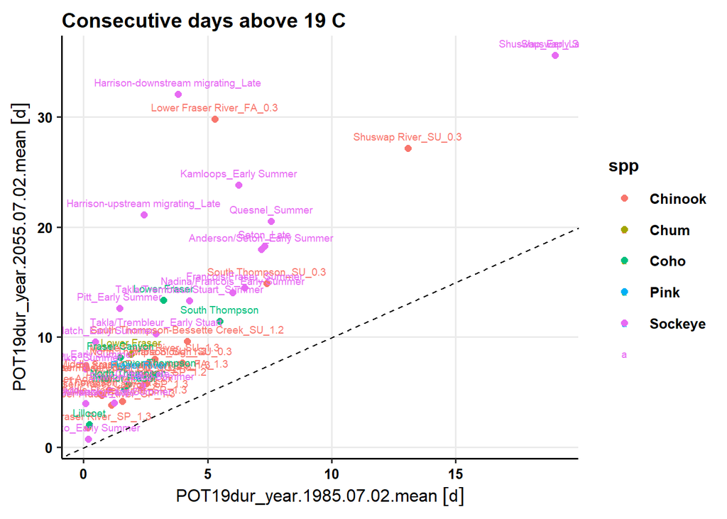

## Spatial plots of PCIC indicators

Plots below show the PCIC gridded model outputs for the Fraser basin for historic and future time periods.

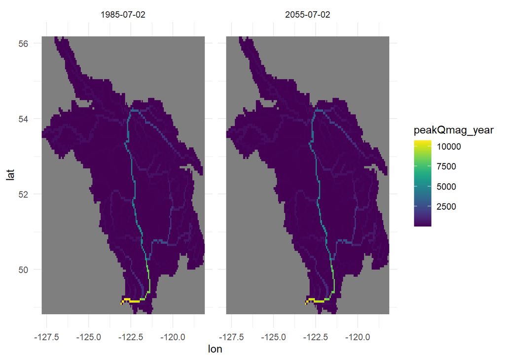

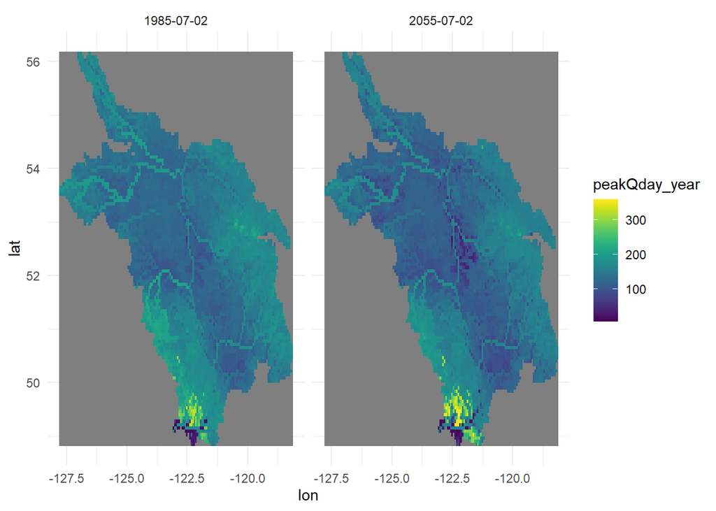

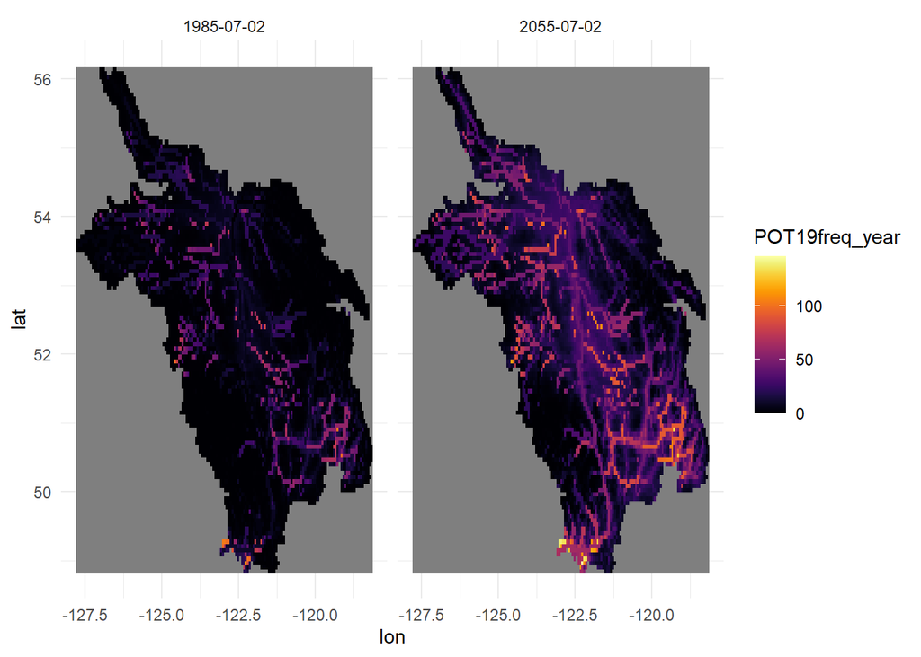

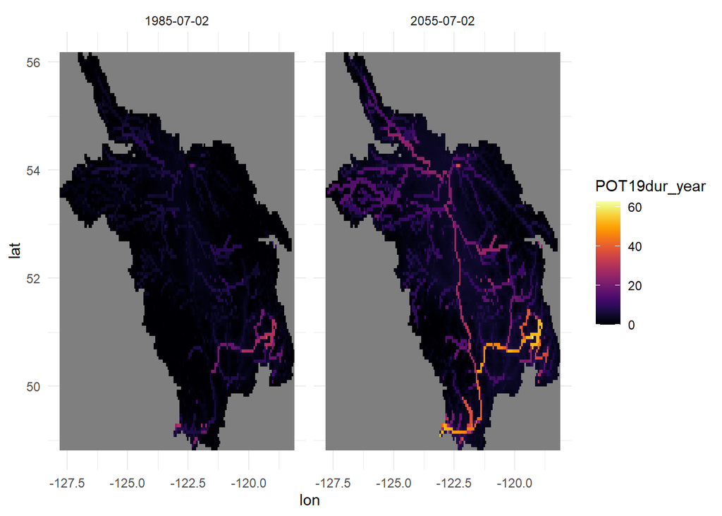

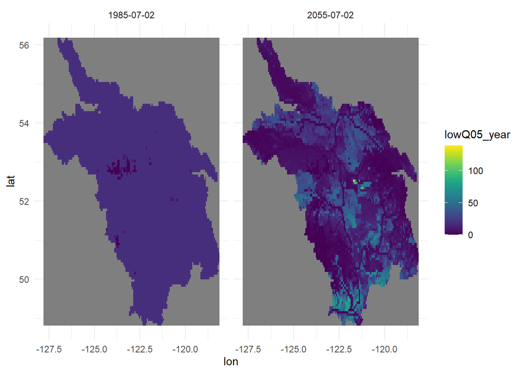

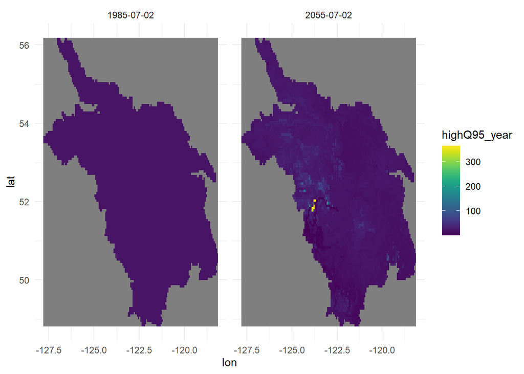

## Summary by CU

Statistics on indicator values for temperature and flow are outputted for each CU below, including spatial plots of the PCIC gridded model output within CU boundaries.

White lines in the plot represent spawning streams for the species within the CU boundary, based on observed and modelled spawning occurrence from the BCFishPass database.

**Currently subsetted to show Coho only**

### Lower Fraser - Coho

| attr | .1985.07.02.mean | .2055.07.02.mean | .diff.mean | .prct_change.mean | .1985.07.02.SD | .2055.07.02.SD |
| --- | --- | --- | --- | --- | --- | --- |
| peakQmag_year | 1170.1 | 1110.2 | -59.9 | 0.9 | 2996.8 | 2837.2 |
| peakQday_year | 195.8 | 203.3 | 7.5 | 1.0 | 74.3 | 95.1 |
| lowQ05_year | 18.3 | 35.2 | 16.9 | 1.9 | 0.0 | 26.5 |
| POT19freq_year | 9.6 | 37.7 | 28.0 | 3.9 | 18.3 | 31.1 |
| POT19dur_year | 3.2 | 13.4 | 10.1 | 4.2 | 4.6 | 15.8 |

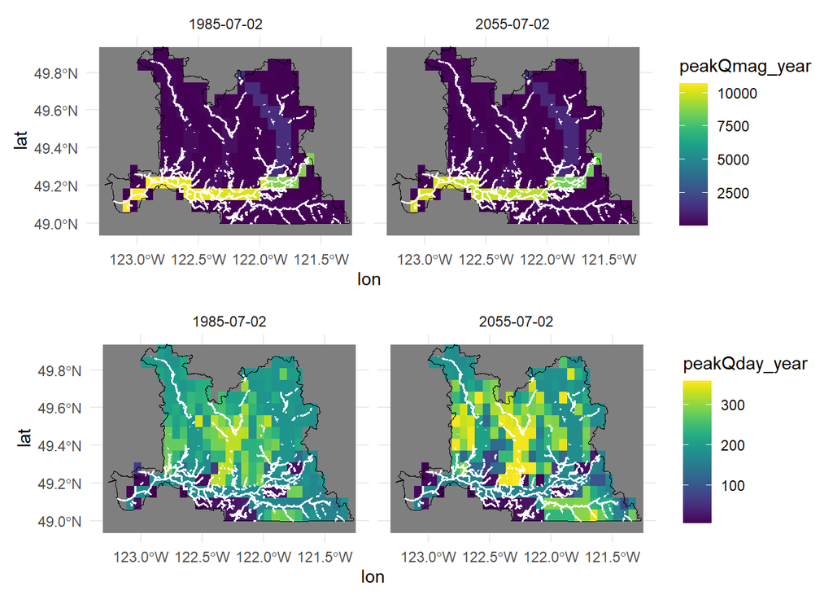

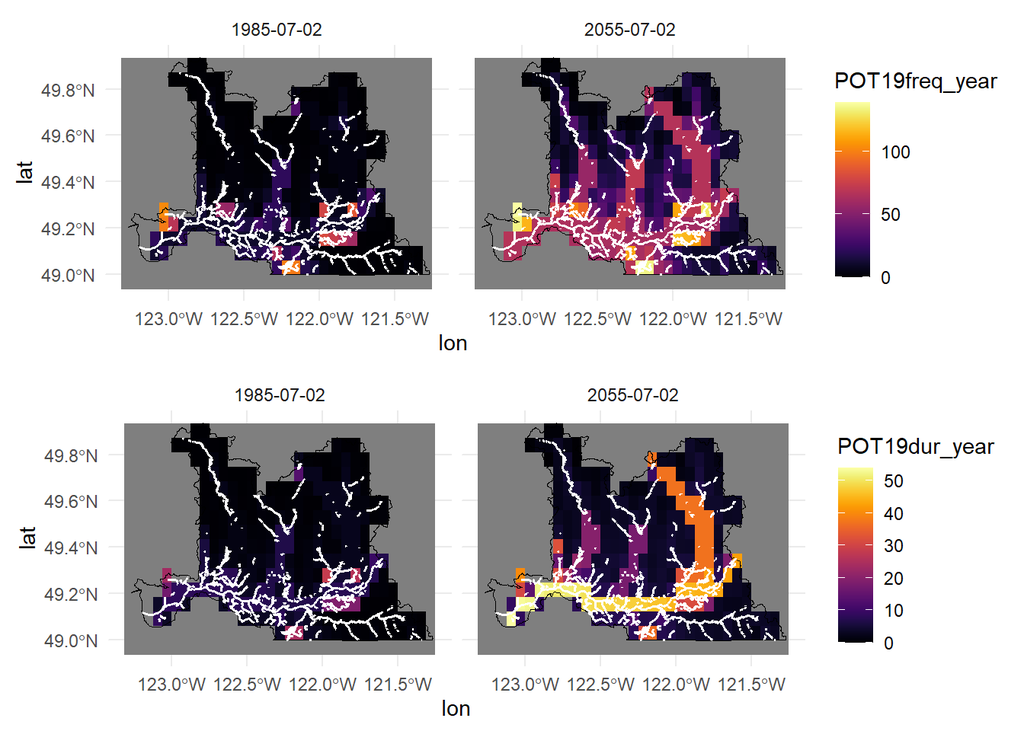

### Lillooet - Coho

| attr | .1985.07.02.mean | .2055.07.02.mean | .diff.mean | .prct_change.mean | .1985.07.02.SD | .2055.07.02.SD |
| --- | --- | --- | --- | --- | --- | --- |
| peakQmag_year | 127.1 | 115.6 | -11.5 | 0.9 | 291.1 | 263.1 |
| peakQday_year | 193.3 | 189.7 | -3.7 | 1.0 | 22.3 | 35.2 |
| lowQ05_year | 18.2 | 9.0 | -9.2 | 0.5 | 1.3 | 15.8 |
| POT19freq_year | 0.4 | 5.8 | 5.5 | 14.7 | 1.1 | 7.9 |
| POT19dur_year | 0.2 | 2.0 | 1.8 | 9.2 | 0.5 | 2.6 |

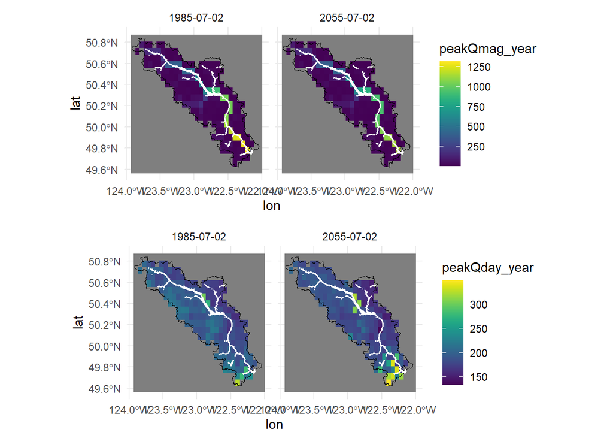

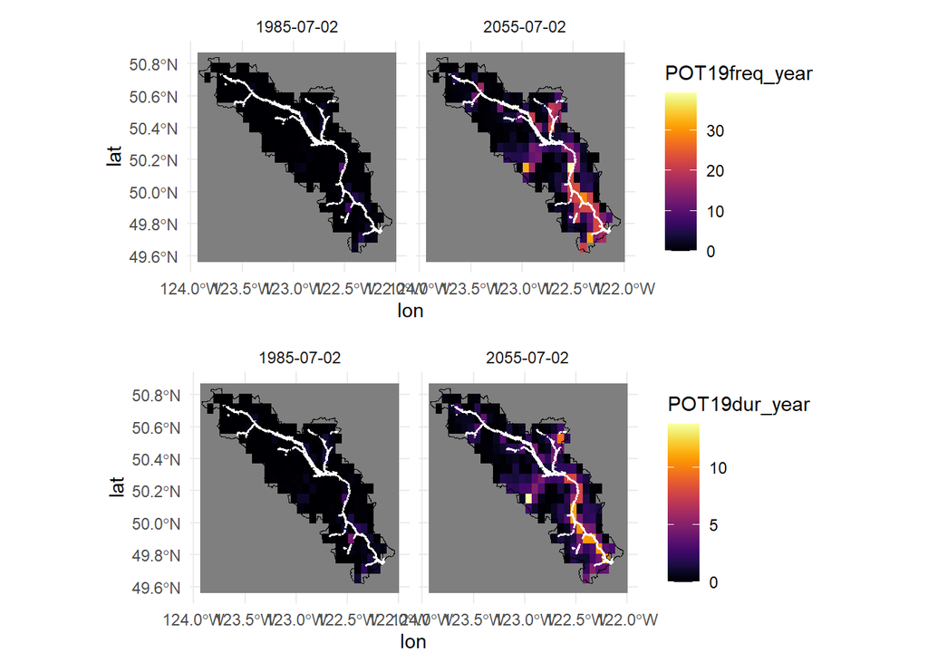

### Fraser Canyon - Coho

| attr | .1985.07.02.mean | .2055.07.02.mean | .diff.mean | .prct_change.mean | .1985.07.02.SD | .2055.07.02.SD |
| --- | --- | --- | --- | --- | --- | --- |
| peakQmag_year | 989.5 | 959.7 | -29.8 | 1.0 | 2663.2 | 2586.0 |
| peakQday_year | 176.4 | 153.3 | -23.1 | 0.9 | 8.6 | 24.9 |
| lowQ05_year | 18.3 | 24.2 | 5.9 | 1.3 | 0.0 | 21.5 |
| POT19freq_year | 2.9 | 21.1 | 18.2 | 7.3 | 4.3 | 18.6 |
| POT19dur_year | 1.5 | 8.1 | 6.7 | 5.5 | 2.0 | 12.2 |

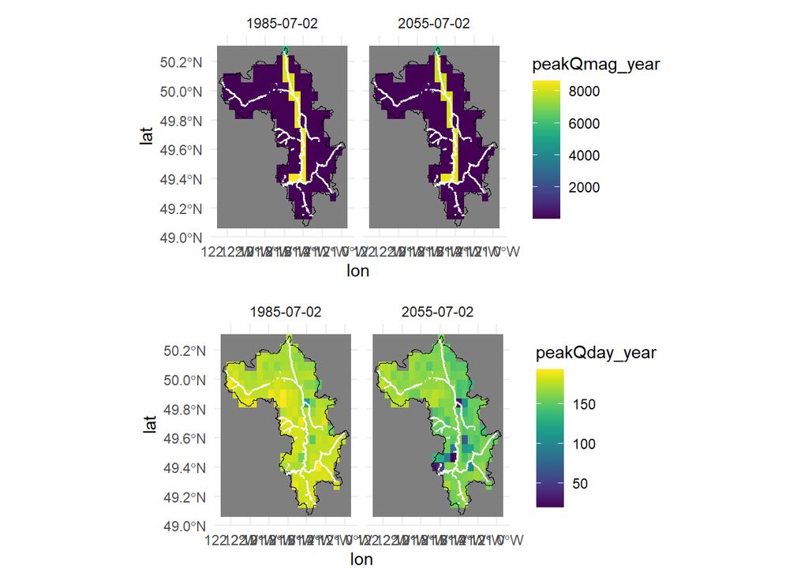

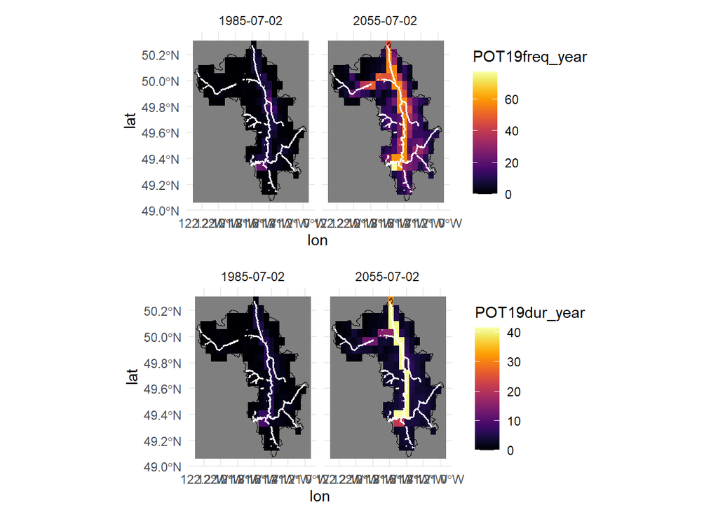

### Interior Fraser - Coho

| attr | .1985.07.02.mean | .2055.07.02.mean | .diff.mean | .prct_change.mean | .1985.07.02.SD | .2055.07.02.SD |
| --- | --- | --- | --- | --- | --- | --- |
| peakQmag_year | 136.3 | 132.8 | -3.5 | 1.0 | 606.3 | 589.9 |
| peakQday_year | 145.4 | 130.6 | -14.8 | 0.9 | 27.6 | 29.3 |
| lowQ05_year | 17.9 | 12.9 | -5.0 | 0.7 | 2.4 | 13.3 |
| POT19freq_year | 5.9 | 20.1 | 14.2 | 3.4 | 11.0 | 18.9 |
| POT19dur_year | 1.6 | 5.2 | 3.6 | 3.2 | 2.0 | 5.5 |

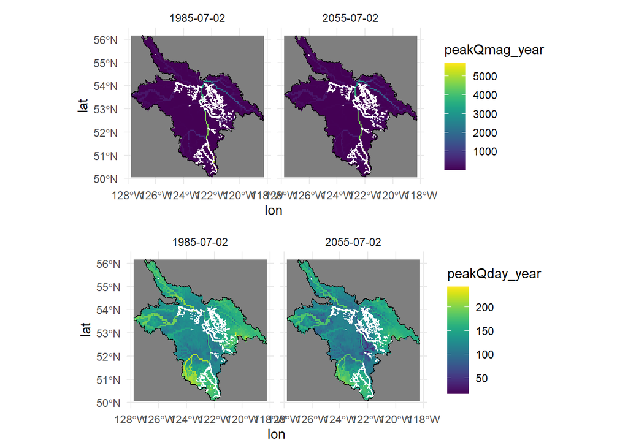

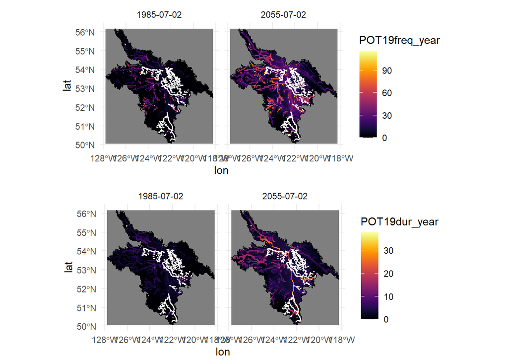

### Lower Thompson - Coho

| attr | .1985.07.02.mean | .2055.07.02.mean | .diff.mean | .prct_change.mean | .1985.07.02.SD | .2055.07.02.SD |
| --- | --- | --- | --- | --- | --- | --- |
| peakQmag_year | 121.7 | 120.5 | -1.2 | 1.0 | 518.3 | 511.9 |
| peakQday_year | 124.6 | 110.2 | -14.3 | 0.9 | 19.4 | 18.9 |
| lowQ05_year | 18.3 | 23.2 | 4.9 | 1.3 | 0.0 | 18.5 |
| POT19freq_year | 10.8 | 29.5 | 18.7 | 2.7 | 15.0 | 21.9 |
| POT19dur_year | 2.9 | 6.6 | 3.7 | 2.3 | 4.1 | 9.3 |

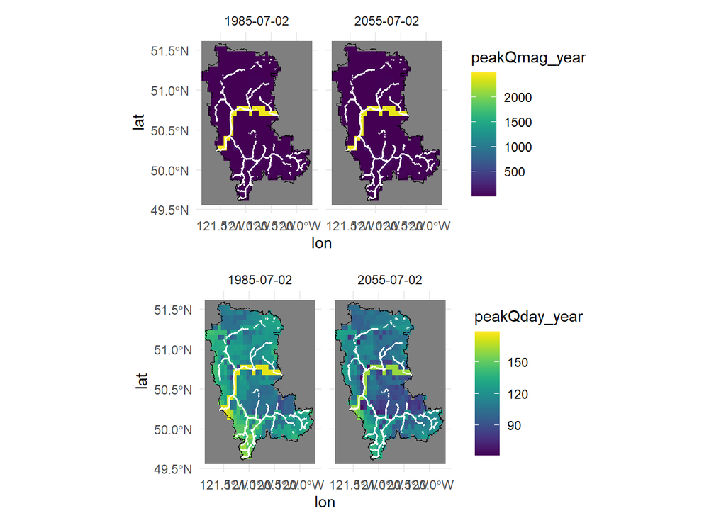

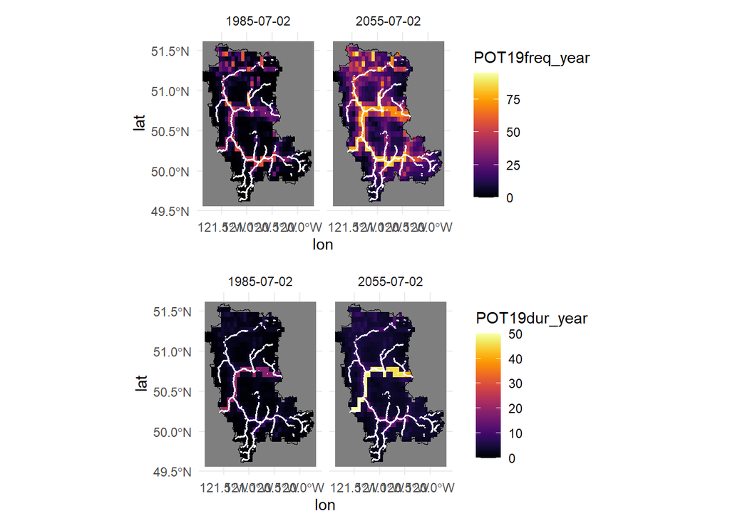

### South Thompson - Coho

| attr | .1985.07.02.mean | .2055.07.02.mean | .diff.mean | .prct_change.mean | .1985.07.02.SD | .2055.07.02.SD |
| --- | --- | --- | --- | --- | --- | --- |
| peakQmag_year | 91.1 | 89.6 | -1.4 | 1.0 | 214.5 | 211.3 |
| peakQday_year | 159.4 | 143.7 | -15.8 | 0.9 | 21.0 | 21.7 |
| lowQ05_year | 18.3 | 13.2 | -5.1 | 0.7 | 0.0 | 11.7 |
| POT19freq_year | 15.6 | 39.3 | 23.7 | 2.5 | 20.3 | 28.0 |
| POT19dur_year | 5.5 | 11.4 | 5.9 | 2.1 | 8.3 | 14.9 |

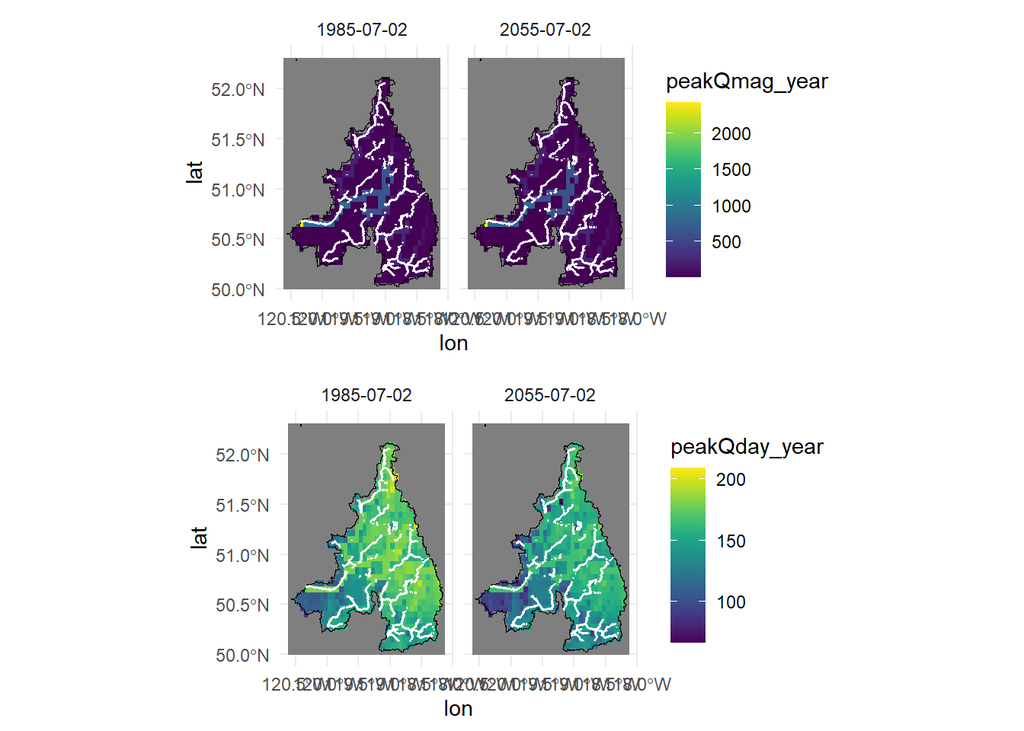

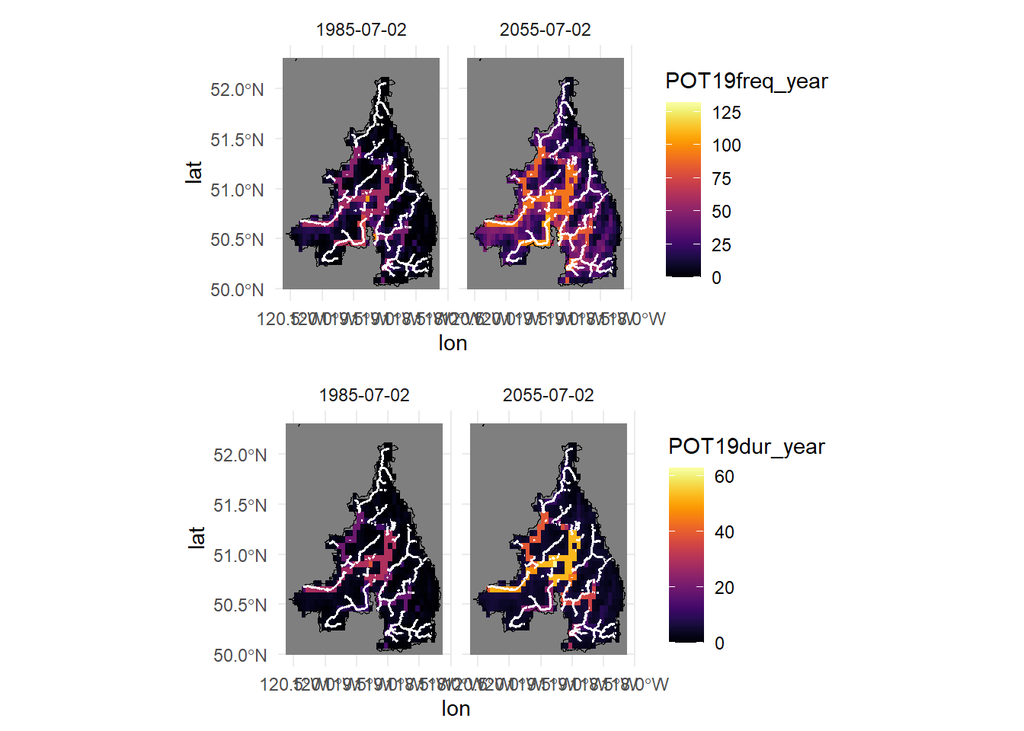

### North Thompson - Coho

| attr | .1985.07.02.mean | .2055.07.02.mean | .diff.mean | .prct_change.mean | .1985.07.02.SD | .2055.07.02.SD |
| --- | --- | --- | --- | --- | --- | --- |
| peakQmag_year | 102.8 | 102.5 | -0.3 | 1.0 | 295.4 | 292.1 |
| peakQday_year | 154.0 | 140.7 | -13.4 | 0.9 | 21.5 | 23.5 |
| lowQ05_year | 18.2 | 11.8 | -6.4 | 0.6 | 1.2 | 12.3 |
| POT19freq_year | 5.8 | 22.5 | 16.7 | 3.9 | 10.7 | 19.7 |
| POT19dur_year | 1.8 | 5.7 | 3.9 | 3.2 | 2.2 | 5.6 |

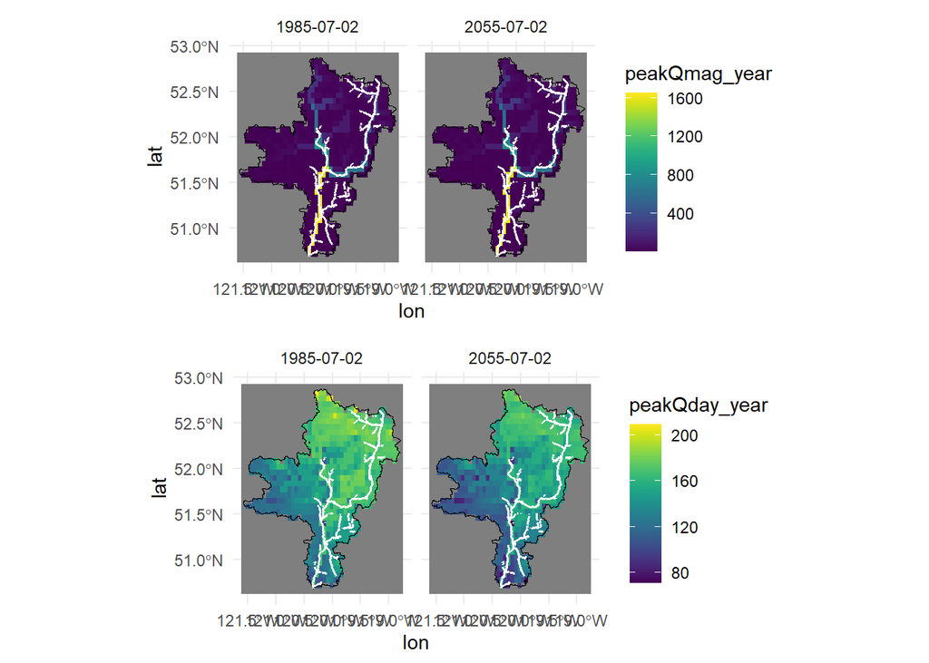

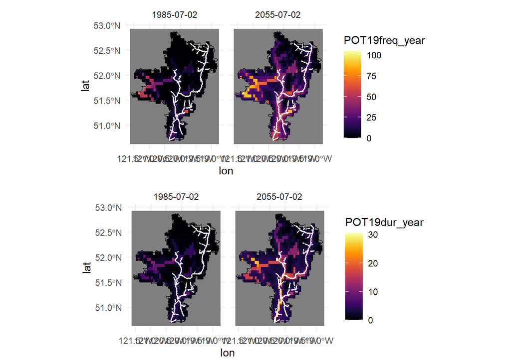